# Análisis descriptivo de registros municipales

RENAMU, serenazgo, videovigilancia e intervenciones municipales

Autor/a

Noam López Villanes

Fecha de publicación

15 de mayo de 2026

## 1 Objetivo de la sesión

En esta sesión trabajaremos con registros municipales de seguridad ciudadana a partir de la RENAMU 2025. El objetivo es aprender a producir un análisis descriptivo univariado ordenado:

1. Importar correctamente una base separada por punto y coma.
2. Revisar estructura, dimensiones, nombres de variables y valores perdidos.
3. Seleccionar variables municipales vinculadas a seguridad ciudadana.
4. Calcular frecuencias, porcentajes, medidas de tendencia central y dispersión.
5. Identificar valores atípicos en conteos municipales.
6. Visualizar distribuciones de serenazgo, videovigilancia e intervenciones.
7. Exportar bases resumidas para ejercicios posteriores.

## 2 Preparación

Si ejecutas este documento por partes, corre primero los chunks de **Instalar paquetes**, **Activar paquetes** y **Ubicar archivos**. Los tres están ocultos en el redenrizado final, pero esos bloques crean los paquetes, funciones y rutas que usan los demás chunks

Esta versión coloca todos los archivos en una sola carpeta, con nombres cortos y sin tildes, para evitar problemas al descargar materiales desde Paideia. El análisis usará `renamu2025.csv`; el diccionario `dict_renamu2025.pdf` sirve para interpretar los códigos de variables.

## 3 Importación

### 3.1 Revisar el separador del archivo

```r
renamu_lectura_incorrecta <- read_csv(
  # read_csv() asume comas, pero este archivo viene separado por punto y coma.
  file.path(ruta_renamu, "renamu2025.csv"),
  n_max = 5,
  show_col_types = FALSE
)

ncol(renamu_lectura_incorrecta)
```

```
[1] 1
```

Cuando una base aparece como una sola columna, no necesariamente está dañada. Muchas veces el problema es el separador: coma, punto y coma, tabulador u otro carácter.

### 3.2 Importar RENAMU correctamente

```r
cargar_renamu_original()

glimpse(renamu_original[, 1:12])
```

```
Rows: 1,891
Columns: 12
$ ano          <chr> "2025", "2025", "2025", "2025", "2025", "2025", "2025", "…
$ idmunici     <chr> "010101", "010102", "010103", "010104", "010105", "010106…
$ ccdd         <chr> "01", "01", "01", "01", "01", "01", "01", "01", "01", "01…
$ ccpp         <chr> "01", "01", "01", "01", "01", "01", "01", "01", "01", "01…
$ ccdi         <chr> "01", "02", "03", "04", "05", "06", "07", "08", "09", "10…
$ ubigeo       <chr> "010101", "010102", "010103", "010104", "010105", "010106…
$ departamento <chr> "AMAZONAS", "AMAZONAS", "AMAZONAS", "AMAZONAS", "AMAZONAS…
$ provincia    <chr> "CHACHAPOYAS", "CHACHAPOYAS", "CHACHAPOYAS", "CHACHAPOYAS…
$ distrito     <chr> "CHACHAPOYAS", "ASUNCION", "BALSAS", "CHETO", "CHILIQUIN"…
$ tipomuni     <chr> "1", "2", "2", "2", "2", "2", "2", "2", "2", "2", "2", "2…
$ vfi          <chr> "1", "1", "1", "1", "1", "1", "1", "1", "1", "1", "1", "1…
$ p04_1        <chr> "2", "3", "1", "2", "3", "2", "3", "2", "1", "2", "2", "2…
```

La base se importa correctamente con `read_delim(delim = ";")`. Mantener inicialmente las columnas como texto ayuda a controlar códigos como `#¡NULO!` antes de convertir variables numéricas.

## 4 Estructura de la base

### 4.1 Dimensiones generales

```r
resumen_base <- tibble(
  base = "RENAMU 2025",
  filas = nrow(renamu_original),
  columnas = ncol(renamu_original)
)

resumen_base
```

| base | filas | columnas |
| --- | --- | --- |
| RENAMU 2025 | 1891 | 1388 |

La RENAMU tiene una fila por municipalidad y muchas columnas porque recoge información de distintos módulos municipales. Para esta sesión no usaremos todo el cuestionario, sino el bloque de seguridad ciudadana.

### 4.2 Seleccionar variables de seguridad

```r
preparar_renamu_seguridad()

renamu_seguridad |>
  select(
    ano,
    ubigeo,
    departamento,
    provincia,
    distrito,
    tipo_municipalidad,
    serenazgo_2025,
    p69_2_t,
    tiene_camaras,
    p70a_7_1,
    tiene_central_videovigilancia,
    total_intervenciones
  ) |>
  head(10)
```

| ano | ubigeo | departamento | provincia | distrito | tipo_municipalidad | serenazgo_2025 | p69_2_t | tiene_camaras | p70a_7_1 | tiene_central_videovigilancia | total_intervenciones |
| --- | --- | --- | --- | --- | --- | --- | --- | --- | --- | --- | --- |
| 2025 | 010101 | AMAZONAS | CHACHAPOYAS | CHACHAPOYAS | Provincial | Sí | 28 | Sí | 14 | Sí | 189 |
| 2025 | 010102 | AMAZONAS | CHACHAPOYAS | ASUNCION | Distrital | No | NA | No | NA | No | 0 |
| 2025 | 010103 | AMAZONAS | CHACHAPOYAS | BALSAS | Distrital | No | NA | No | NA | No | 0 |
| 2025 | 010104 | AMAZONAS | CHACHAPOYAS | CHETO | Distrital | No | NA | No | NA | No | 0 |
| 2025 | 010105 | AMAZONAS | CHACHAPOYAS | CHILIQUIN | Distrital | No | NA | No | NA | No | 2 |
| 2025 | 010106 | AMAZONAS | CHACHAPOYAS | CHUQUIBAMBA | Distrital | No | NA | No | NA | No | 0 |
| 2025 | 010107 | AMAZONAS | CHACHAPOYAS | GRANADA | Distrital | No | NA | No | NA | No | 0 |
| 2025 | 010108 | AMAZONAS | CHACHAPOYAS | HUANCAS | Distrital | No | NA | No | NA | No | 0 |
| 2025 | 010109 | AMAZONAS | CHACHAPOYAS | LA JALCA | Distrital | No | NA | No | NA | No | 0 |
| 2025 | 010110 | AMAZONAS | CHACHAPOYAS | LEIMEBAMBA | Distrital | No | NA | No | NA | No | 11 |

Trabajar con un subconjunto permite concentrar la sesión en preguntas sustantivas: si el municipio brinda serenazgo, con cuántos efectivos cuenta, qué equipamiento tiene y cuántas intervenciones registra.

### 4.3 Valores perdidos

```r
preparar_renamu_seguridad()

perdidos_seguridad <- renamu_seguridad |>
  summarise(
    across(
      c(p69_2_t, p70a_1_1, p70a_7_1, p70a_10_1, p71a_1, total_intervenciones),
      ~ sum(is.na(.x))
    )
  ) |>
  pivot_longer(
    cols = everything(),
    names_to = "variable",
    values_to = "perdidos"
  ) |>
  mutate(porcentaje = perdidos / nrow(renamu_seguridad))

perdidos_seguridad
```

| variable | perdidos | porcentaje |
| --- | --- | --- |
| p69_2_t | 626 | 0.3310418 |
| p70a_1_1 | 913 | 0.4828133 |
| p70a_7_1 | 1257 | 0.6647277 |
| p70a_10_1 | 1395 | 0.7377049 |
| p71a_1 | 1382 | 0.7308302 |
| total_intervenciones | 0 | 0.0000000 |

Los valores perdidos no siempre son errores. En este caso, varios conteos aparecen vacíos porque la municipalidad respondió que no tiene el servicio, equipo o intervención correspondiente.

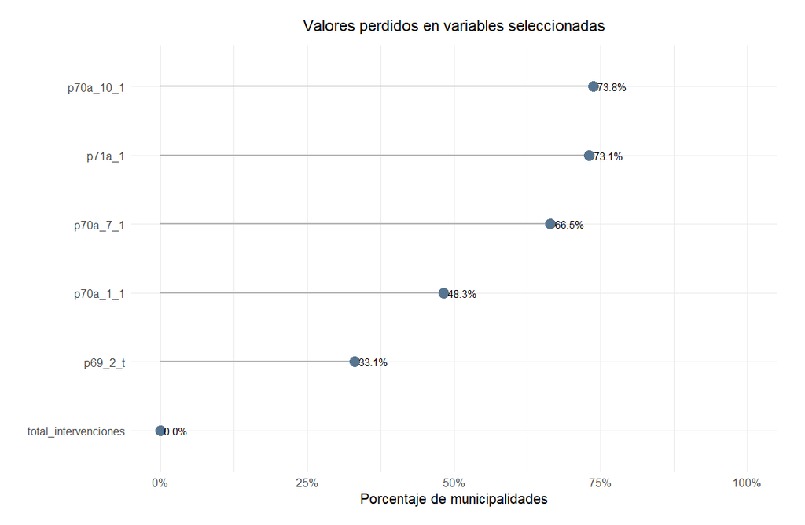

```r
perdidos_seguridad |>
  ggplot(aes(x = reorder(variable, porcentaje), y = porcentaje)) +
  geom_segment(
    aes(xend = variable, y = 0, yend = porcentaje),
    color = "#b8b8b8",
    linewidth = 0.8
  ) +
  geom_point(size = 4, color = "#577590") +
  geom_text(
    aes(label = percent(porcentaje, accuracy = 0.1)),
    hjust = -0.15,
    size = 3.2
  ) +
  coord_flip() +
  scale_y_continuous(labels = percent_format(), limits = c(0, 1)) +
  labs(
    title = "Valores perdidos en variables seleccionadas",
    x = NULL,
    y = "Porcentaje de municipalidades"
  ) +
  tema_sesion()
```

El gráfico permite distinguir variables casi completas de variables condicionadas por filtros del cuestionario. En encuestas o registros administrativos, el patrón de pérdida suele depender de la lógica de preguntas.

### 4.4 Duplicados por ubigeo

```r
duplicados_ubigeo <- renamu_seguridad |>
  count(ubigeo, sort = TRUE) |>
  filter(n > 1)

duplicados_ubigeo
```

| ubigeo | n |
| --- | --- |

Si esta tabla queda vacía, cada municipalidad aparece una sola vez por `ubigeo`. Esa revisión es básica antes de resumir información territorial.

## 5 Cobertura del servicio de serenazgo

### 5.1 Serenazgo al 31 de marzo de 2025

```r
preparar_renamu_seguridad()

cobertura_serenazgo <- renamu_seguridad |>
  count(serenazgo_2025, name = "municipalidades") |>
  mutate(porcentaje = municipalidades / sum(municipalidades))

cobertura_serenazgo
```

| serenazgo_2025 | municipalidades | porcentaje |
| --- | --- | --- |
| No | 626 | 0.3310418 |
| Sí | 1265 | 0.6689582 |

Esta tabla responde una primera pregunta descriptiva: cuántas municipalidades declaran brindar serenazgo al 31 de marzo de 2025.

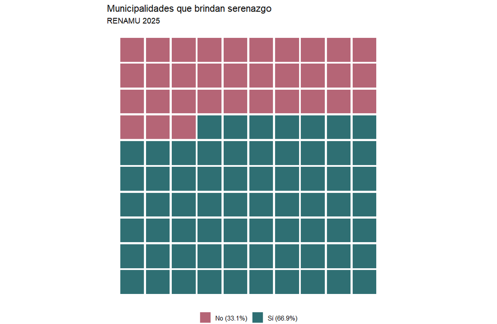

```r
cobertura_serenazgo |>
  filter(serenazgo_2025 != "Sin dato") |>
  mutate(
    bloques = round(porcentaje * 100),
    estado = str_c(
      serenazgo_2025,
      " (",
      percent(porcentaje, accuracy = 0.1),
      ")"
    )
  ) |>
  uncount(bloques) |>
  mutate(
    celda = row_number(),
    columna = (celda - 1) %% 10,
    fila = (celda - 1) %/% 10
  ) |>
  ggplot(aes(x = columna, y = fila, fill = estado)) +
  geom_tile(
    color = "white",
    linewidth = 0.6,
    width = 0.95,
    height = 0.95
  ) +
  coord_equal() +
  scale_y_reverse() +
  scale_fill_manual(values = c("#b56576", "#2f6f73")) +
  labs(
    title = "Municipalidades que brindan serenazgo",
    subtitle = "RENAMU 2025",
    fill = NULL
  ) +
  theme_void(base_size = 11) +
  theme(legend.position = "bottom")
```

La visualización muestra la cobertura general del servicio. Es una lectura univariada porque analiza una sola variable categórica.

### 5.2 Cobertura por departamento

```r
serenazgo_departamento <- renamu_seguridad |>
  group_by(departamento) |>
  summarise(
    municipalidades = n(),
    con_serenazgo = sum(p69_2 == 1, na.rm = TRUE),
    porcentaje_serenazgo = con_serenazgo / municipalidades,
    .groups = "drop"
  ) |>
  arrange(desc(porcentaje_serenazgo))

serenazgo_departamento
```

| departamento | municipalidades | con_serenazgo | porcentaje_serenazgo |
| --- | --- | --- | --- |
| CALLAO | 7 | 7 | 1.0000000 |
| UCAYALI | 19 | 19 | 1.0000000 |
| PUNO | 110 | 108 | 0.9818182 |
| ICA | 43 | 41 | 0.9534884 |
| CUSCO | 116 | 109 | 0.9396552 |
| MADRE DE DIOS | 11 | 10 | 0.9090909 |
| HUANUCO | 84 | 75 | 0.8928571 |
| PASCO | 29 | 25 | 0.8620690 |
| TACNA | 28 | 24 | 0.8571429 |
| TUMBES | 13 | 11 | 0.8461538 |

[output cut: 15 more lines]

Aunque el foco de la sesión es descriptivo, agrupar por departamento ayuda a mostrar heterogeneidad territorial sin pasar todavía a modelos explicativos.

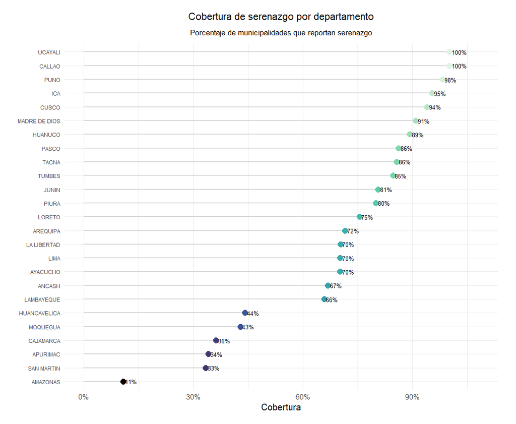

```r
serenazgo_departamento |>
  mutate(departamento = reorder(departamento, porcentaje_serenazgo)) |>
  ggplot(aes(x = porcentaje_serenazgo, y = departamento)) +
  geom_segment(
    aes(x = 0, xend = porcentaje_serenazgo, yend = departamento),
    color = "#d8d8d8",
    linewidth = 0.7
  ) +
  geom_point(aes(color = porcentaje_serenazgo), size = 3.2) +
  geom_text(
    aes(label = percent(porcentaje_serenazgo, accuracy = 1)),
    hjust = -0.18,
    size = 2.7
  ) +
  scale_x_continuous(labels = percent_format(), limits = c(0, 1.08)) +
  scale_color_paletteer_c("viridis::mako", labels = percent_format()) +
  labs(
    title = "Cobertura de serenazgo por departamento",
    subtitle = "Porcentaje de municipalidades que reportan serenazgo",
    x = "Cobertura",
    y = NULL,
    fill = "Cobertura"
  ) +
  tema_sesion() +
  theme(
    axis.text.y = element_text(size = 7.4),
    legend.position = "none"
  )
```

El gráfico ordenado facilita comparar departamentos sin apretar las etiquetas. En análisis descriptivo, ordenar categorías suele ser más útil que dejarlas alfabéticamente.

## 6 Efectivos de serenazgo

### 6.1 Distribución general

```r
efectivos_serenazgo <- renamu_seguridad |>
  filter(p69_2 == 1) |>
  summarise(
    municipalidades = n(),
    minimo = min(p69_2_t, na.rm = TRUE),
    q1 = quantile(p69_2_t, 0.25, na.rm = TRUE),
    mediana = median(p69_2_t, na.rm = TRUE),
    promedio = mean(p69_2_t, na.rm = TRUE),
    q3 = quantile(p69_2_t, 0.75, na.rm = TRUE),
    maximo = max(p69_2_t, na.rm = TRUE)
  )

efectivos_serenazgo
```

| municipalidades | minimo | q1 | mediana | promedio | q3 | maximo |
| --- | --- | --- | --- | --- | --- | --- |
| 1265 | 1 | 3 | 7 | 33.46482 | 20 | 1534 |

La media puede ser mucho mayor que la mediana cuando pocas municipalidades concentran muchos efectivos. Por eso conviene reportar varias medidas, no solo el promedio.

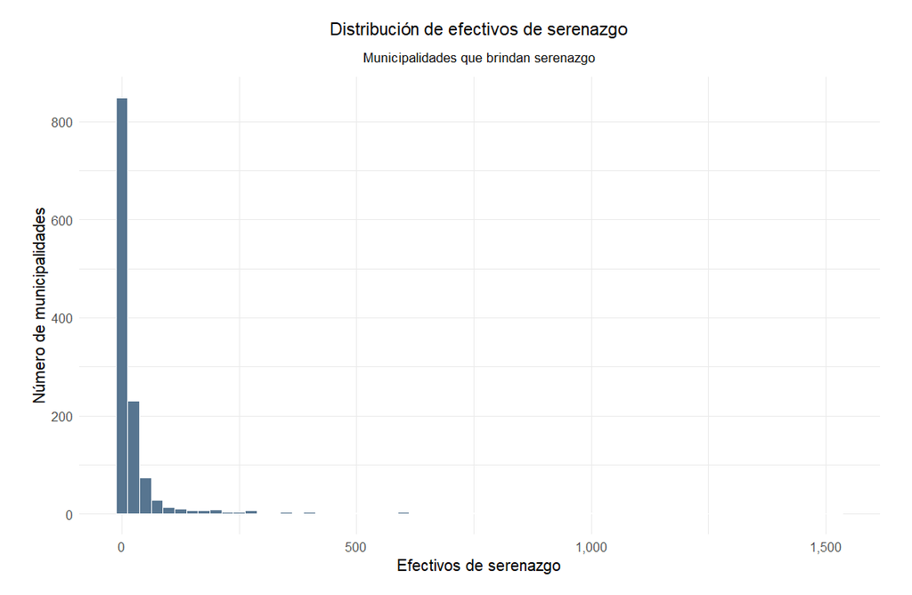

```r
renamu_seguridad |>
  filter(p69_2 == 1, !is.na(p69_2_t)) |>
  ggplot(aes(x = p69_2_t)) +
  geom_histogram(binwidth = 25, fill = "#577590", color = "white") +
  scale_x_continuous(labels = comma_format()) +
  labs(
    title = "Distribución de efectivos de serenazgo",
    subtitle = "Municipalidades que brindan serenazgo",
    x = "Efectivos de serenazgo",
    y = "Número de municipalidades"
  ) +
  tema_sesion()
```

La distribución está concentrada en valores bajos y tiene una cola larga. Este patrón es común en registros territoriales: pocas unidades grandes pueden dominar la escala.

### 6.2 Valores atípicos

```r
limites_efectivos <- renamu_seguridad |>
  filter(p69_2 == 1, !is.na(p69_2_t)) |>
  summarise(
    q1 = quantile(p69_2_t, 0.25),
    q3 = quantile(p69_2_t, 0.75),
    iqr = IQR(p69_2_t),
    limite_superior = q3 + 1.5 * iqr
  )

municipalidades_atipicas <- renamu_seguridad |>
  filter(p69_2 == 1, p69_2_t > limites_efectivos$limite_superior) |>
  arrange(desc(p69_2_t)) |>
  select(departamento, provincia, distrito, p69_2_t)

limites_efectivos
```

| q1 | q3 | iqr | limite_superior |
| --- | --- | --- | --- |
| 3 | 20 | 17 | 45.5 |

```r
municipalidades_atipicas |> head(15)
```

| departamento | provincia | distrito | p69_2_t |
| --- | --- | --- | --- |
| LIMA | LIMA | SANTIAGO DE SURCO | 1534 |
| LIMA | LIMA | SAN JUAN DE LURIGANCHO | 1427 |
| LIMA | LIMA | MIRAFLORES | 997 |
| LIMA | LIMA | LIMA | 989 |
| LIMA | LIMA | SAN ISIDRO | 960 |
| LIMA | LIMA | SAN BORJA | 900 |
| LIMA | LIMA | PUENTE PIEDRA | 761 |
| LA LIBERTAD | TRUJILLO | TRUJILLO | 740 |
| LIMA | LIMA | JESUS MARIA | 723 |
| LIMA | LIMA | LURIN | 655 |

[output cut: 5 more lines]

Un valor atípico no debe borrarse automáticamente. En conteos municipales puede representar una capital provincial, un distrito grande o una diferencia real de capacidad institucional.

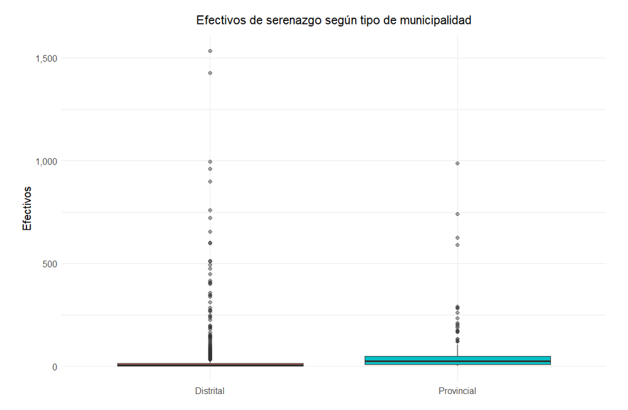

```r
renamu_seguridad |>
  filter(p69_2 == 1, !is.na(p69_2_t)) |>
  ggplot(aes(x = tipo_municipalidad, y = p69_2_t, fill = tipo_municipalidad)) +
  geom_boxplot(show.legend = FALSE, outlier.alpha = 0.45) +
  scale_y_continuous(labels = comma_format()) +
  labs(
    title = "Efectivos de serenazgo según tipo de municipalidad",
    x = NULL,
    y = "Efectivos"
  ) +
  tema_sesion()
```

El boxplot permite comparar distribución, mediana y valores extremos entre municipalidades provinciales y distritales. Es útil cuando la variable numérica tiene mucha dispersión.

### 6.3 Composición por sexo

```r
efectivos_sexo <- renamu_seguridad |>
  filter(p69_2 == 1) |>
  summarise(
    hombres = sum(p69_2_h, na.rm = TRUE),
    mujeres = sum(p69_2_m, na.rm = TRUE)
  ) |>
  pivot_longer(
    cols = everything(),
    names_to = "sexo",
    values_to = "efectivos"
  ) |>
  mutate(porcentaje = efectivos / sum(efectivos))

efectivos_sexo
```

| sexo | efectivos | porcentaje |
| --- | --- | --- |
| hombres | 33207 | 0.7844235 |
| mujeres | 9126 | 0.2155765 |

Esta tabla muestra la composición agregada del personal de serenazgo por sexo. La interpretación debe hacerse con cuidado porque no es una tasa por municipalidad, sino un total acumulado.

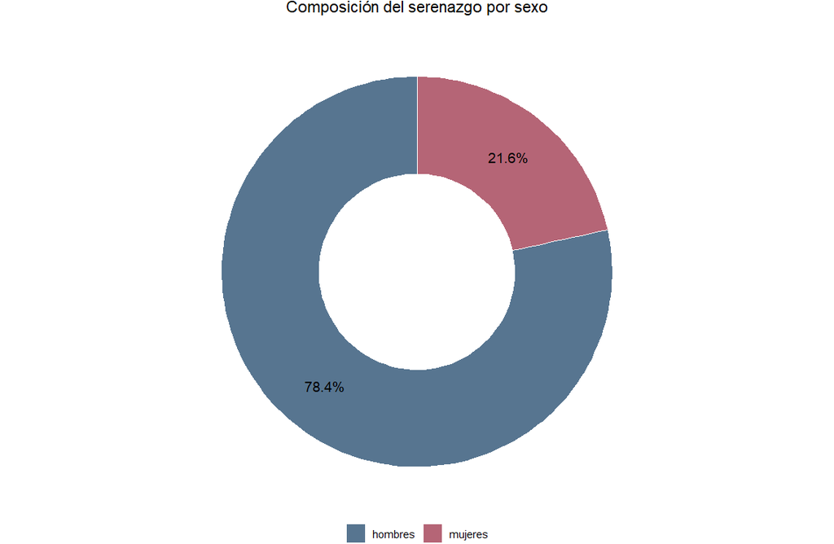

```r
efectivos_sexo |>
  ggplot(aes(x = 2, y = porcentaje, fill = sexo)) +
  geom_col(color = "white", width = 1) +
  coord_polar(theta = "y") +
  xlim(0.5, 2.5) +
  geom_text(
    aes(label = percent(porcentaje, accuracy = 0.1)),
    position = position_stack(vjust = 0.5),
    size = 4
  ) +
  scale_fill_manual(values = c("hombres" = "#577590", "mujeres" = "#b56576")) +
  labs(
    title = "Composición del serenazgo por sexo",
    fill = NULL
  ) +
  theme_void(base_size = 11) +
  theme(
    plot.title = element_text(size = 13, hjust = 0.5, margin = margin(b = 10)),
    legend.position = "bottom"
  )
```

El gráfico permite observar rápidamente la composición del personal. Para profundizar, podría calcularse el porcentaje de mujeres dentro de cada municipalidad.

## 7 Equipamiento e infraestructura

### 7.1 Variables principales de equipamiento

```r
equipamiento_resumen <- renamu_seguridad |>
  summarise(
    auto_o_camioneta = sum(p70_1 == 1, na.rm = TRUE),
    radio_comunicador = sum(p70_6 == 1, na.rm = TRUE),
    camara_videovigilancia = sum(p70_7 == 1, na.rm = TRUE),
    central_videovigilancia = sum(p70_10 == 1, na.rm = TRUE),
    chaleco_antibalas = sum(p70_13 == 1, na.rm = TRUE),
    municipalidades = n()
  ) |>
  pivot_longer(
    cols = -municipalidades,
    names_to = "recurso",
    values_to = "municipalidades_con_recurso"
  ) |>
  mutate(
    porcentaje = municipalidades_con_recurso / municipalidades,
    recurso = str_replace_all(recurso, "_", " ")
  ) |>
  arrange(desc(porcentaje))

equipamiento_resumen
```

| municipalidades | recurso | municipalidades_con_recurso | porcentaje |
| --- | --- | --- | --- |
| 1891 | auto o camioneta | 978 | 0.5171867 |
| 1891 | camara videovigilancia | 634 | 0.3352723 |
| 1891 | radio comunicador | 531 | 0.2808038 |
| 1891 | central videovigilancia | 496 | 0.2622951 |
| 1891 | chaleco antibalas | 329 | 0.1739820 |

Esta tabla compara la presencia de distintos recursos municipales. La lectura sigue siendo univariada por recurso, pero el formato permite ponerlos en una misma vista.

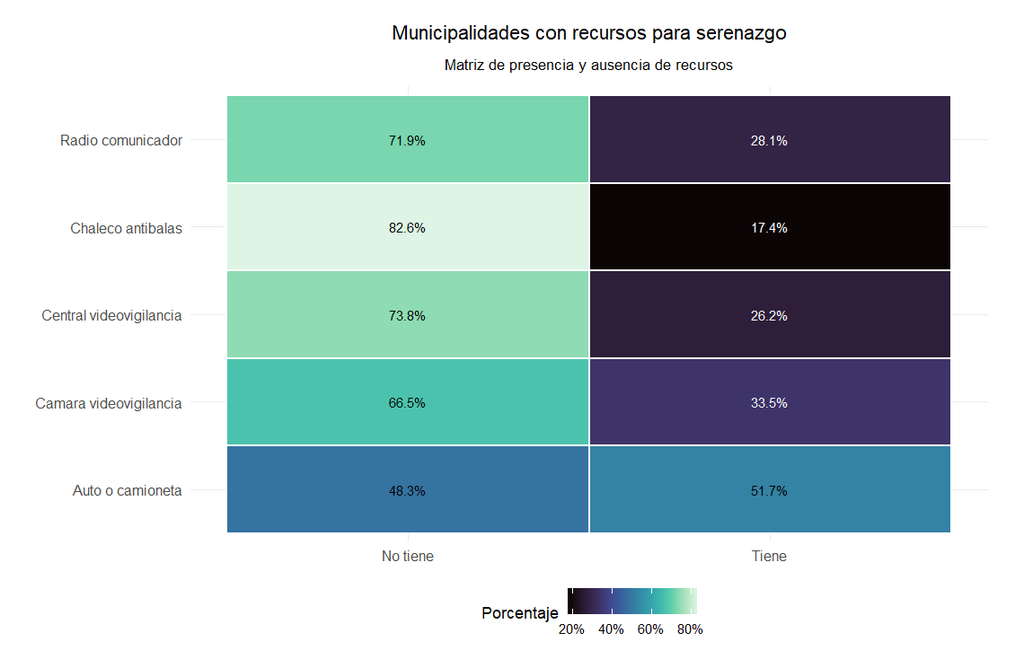

```r
equipamiento_resumen |>
  mutate(
    recurso = str_to_sentence(recurso),
    no_tiene = 1 - porcentaje
  ) |>
  select(recurso, tiene = porcentaje, no_tiene) |>
  pivot_longer(
    cols = c(tiene, no_tiene),
    names_to = "estado",
    values_to = "porcentaje"
  ) |>
  mutate(
    color_texto = if_else(porcentaje < 0.45, "white", "black")
  ) |>
  ggplot(aes(x = estado, y = reorder(recurso, porcentaje), fill = porcentaje)) +
  geom_tile(color = "white", linewidth = 0.7) +
  geom_text(
    aes(label = percent(porcentaje, accuracy = 0.1), color = color_texto),
    size = 3.2
  ) +
  scale_x_discrete(labels = c("no_tiene" = "No tiene", "tiene" = "Tiene")) +
  scale_fill_paletteer_c("viridis::mako", labels = percent_format()) +
  scale_color_identity() +
  labs(
    title = "Municipalidades con recursos para serenazgo",
    subtitle = "Matriz de presencia y ausencia de recursos",
    x = NULL,
    y = NULL,
    fill = "Porcentaje"
  ) +
  tema_sesion()
```

### 7.2 Cámaras de videovigilancia

```r
camaras_resumen <- renamu_seguridad |>
  filter(p70_7 == 1) |>
  summarise(
    municipalidades_con_camaras = n(),
    total_camaras = sum(p70a_7_1, na.rm = TRUE),
    camaras_operativas = sum(p70a_7_2, na.rm = TRUE),
    camaras_no_operativas = sum(p70a_7_3, na.rm = TRUE),
    camaras_integradas_pnp = sum(p70a_7_4, na.rm = TRUE),
    porcentaje_operativas = camaras_operativas / total_camaras,
    porcentaje_integradas_pnp = camaras_integradas_pnp / camaras_operativas
  )

camaras_resumen
```

| municipalidades_con_camaras | total_camaras | camaras_operativas | camaras_no_operativas | camaras_integradas_pnp | porcentaje_operativas | porcentaje_integradas_pnp |
| --- | --- | --- | --- | --- | --- | --- |
| 634 | 23461 | 19737 | 3724 | 3921 | 0.8412685 | 0.1986624 |

No basta con saber si una municipalidad tiene cámaras. Para gestión de seguridad, interesa cuántas están operativas y cuántas están integradas a la PNP.

```r
camaras_departamento <- renamu_seguridad |>
  group_by(departamento) |>
  summarise(
    municipalidades = n(),
    con_camaras = sum(p70_7 == 1, na.rm = TRUE),
    total_camaras = sum(p70a_7_1, na.rm = TRUE),
    camaras_operativas = sum(p70a_7_2, na.rm = TRUE),
    camaras_no_operativas = sum(p70a_7_3, na.rm = TRUE),
    .groups = "drop"
  ) |>
  mutate(
    porcentaje_con_camaras = con_camaras / municipalidades,
    porcentaje_operativas = camaras_operativas / total_camaras
  ) |>
  arrange(desc(total_camaras))

camaras_departamento
```

| departamento | municipalidades | con_camaras | total_camaras | camaras_operativas | camaras_no_operativas | porcentaje_con_camaras | porcentaje_operativas |
| --- | --- | --- | --- | --- | --- | --- | --- |
| LIMA | 171 | 90 | 10475 | 9484 | 991 | 0.52631579 | 0.9053938 |
| AREQUIPA | 109 | 51 | 2347 | 1861 | 486 | 0.46788991 | 0.7929271 |
| CALLAO | 7 | 7 | 1192 | 884 | 308 | 1.00000000 | 0.7416107 |
| CUSCO | 116 | 59 | 1165 | 982 | 183 | 0.50862069 | 0.8429185 |
| LA LIBERTAD | 84 | 35 | 1153 | 736 | 417 | 0.41666667 | 0.6383348 |
| ANCASH | 166 | 58 | 807 | 676 | 131 | 0.34939759 | 0.8376704 |
| ICA | 43 | 26 | 679 | 589 | 90 | 0.60465116 | 0.8674521 |
| JUNIN | 124 | 51 | 677 | 525 | 152 | 0.41129032 | 0.7754801 |
| PIURA | 65 | 20 | 619 | 444 | 175 | 0.30769231 | 0.7172859 |
| AYACUCHO | 124 | 31 | 499 | 384 | 115 | 0.25000000 | 0.7695391 |

[output cut: 15 more lines]

Este resumen muestra tanto cobertura municipal como volumen de cámaras. Un departamento puede tener muchas cámaras por pocas municipalidades grandes, o una cobertura más distribuida.

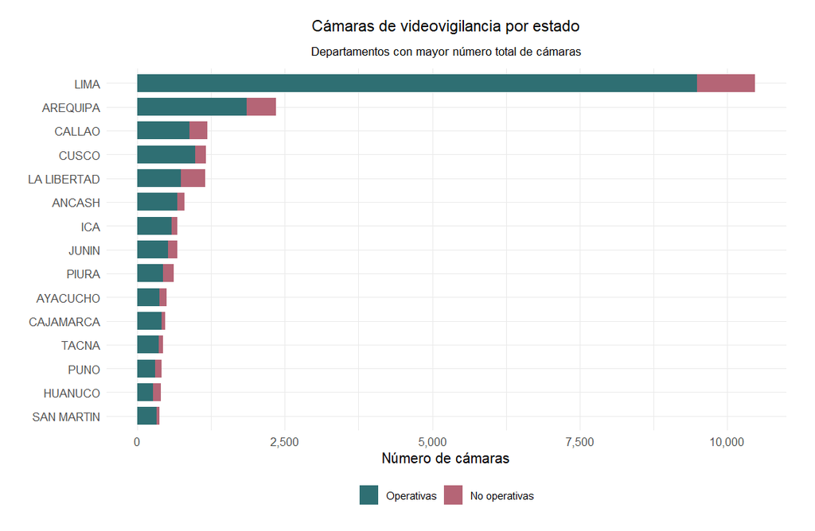

```r
camaras_departamento |>
  slice_max(total_camaras, n = 15) |>
  mutate(
    departamento = reorder(departamento, total_camaras)
  ) |>
  select(departamento, camaras_operativas, camaras_no_operativas) |>
  pivot_longer(
    cols = c(camaras_operativas, camaras_no_operativas),
    names_to = "estado",
    values_to = "camaras"
  ) |>
  ggplot(aes(x = departamento, y = camaras, fill = estado)) +
  geom_col(width = 0.75) +
  coord_flip() +
  scale_y_continuous(labels = comma_format()) +
  scale_fill_manual(
    breaks = c("camaras_operativas", "camaras_no_operativas"),
    values = c(
      "camaras_operativas" = "#2f6f73",
      "camaras_no_operativas" = "#b56576"
    ),
    labels = c("Operativas", "No operativas")
  ) +
  labs(
    title = "Cámaras de videovigilancia por estado",
    subtitle = "Departamentos con mayor número total de cámaras",
    x = NULL,
    y = "Número de cámaras",
    fill = NULL
  ) +
  tema_sesion()
```

El ranking permite ubicar la concentración del equipamiento. En este gráfico, el tramo verde corresponde a cámaras operativas y el tramo rosa a cámaras no operativas. La lectura principal es doble: dónde se concentra el volumen de cámaras y qué parte de ese equipamiento está fuera de operación.

## 8 Intervenciones registradas por serenazgo

### 8.1 Total por tipo de intervención

```r
intervenciones_larga <- renamu_seguridad |>
  select(
    ubigeo,
    departamento,
    provincia,
    distrito,
    robo_transeuntes = p71a_1,
    robo_domicilio = p71a_2,
    robo_vehiculos = p71a_3,
    robo_autopartes = p71a_4,
    robo_establecimientos = p71a_5,
    alcohol_via_publica = p71a_6,
    consumo_drogas = p71a_7,
    accidentes_transito = p71a_8,
    comercio_informal = p71a_9,
    violencia_familiar = p71a_10,
    pandillaje = p71a_11,
    otro = p71a_12
  ) |>
  pivot_longer(
    cols = -c(ubigeo, departamento, provincia, distrito),
    names_to = "tipo_intervencion",
    values_to = "intervenciones"
  )

intervenciones_tipo <- intervenciones_larga |>
  group_by(tipo_intervencion) |>
  summarise(
    intervenciones = sum(intervenciones, na.rm = TRUE),
    municipalidades_con_registro = sum(intervenciones > 0, na.rm = TRUE),
    .groups = "drop"
  ) |>
  mutate(porcentaje = intervenciones / sum(intervenciones)) |>
  arrange(desc(intervenciones))

intervenciones_tipo
```

| tipo_intervencion | intervenciones | municipalidades_con_registro | porcentaje |
| --- | --- | --- | --- |
| alcohol_via_publica | 573834 | 1 | 0.460526886 |
| consumo_drogas | 311336 | 1 | 0.249860759 |
| comercio_informal | 162510 | 1 | 0.130421384 |
| accidentes_transito | 70422 | 1 | 0.056516735 |
| violencia_familiar | 48336 | 1 | 0.038791754 |
| robo_transeuntes | 28713 | 1 | 0.023043438 |
| pandillaje | 12001 | 1 | 0.009631327 |
| otro | 10942 | 1 | 0.008781434 |
| robo_domicilio | 10461 | 1 | 0.008395410 |
| robo_vehiculos | 6738 | 1 | 0.005407540 |

[output cut: 2 more lines]

Esta tabla permite identificar qué tipos de intervención concentran más registros de serenazgo. El total depende tanto de la incidencia del problema como de la capacidad municipal de registrar intervenciones.

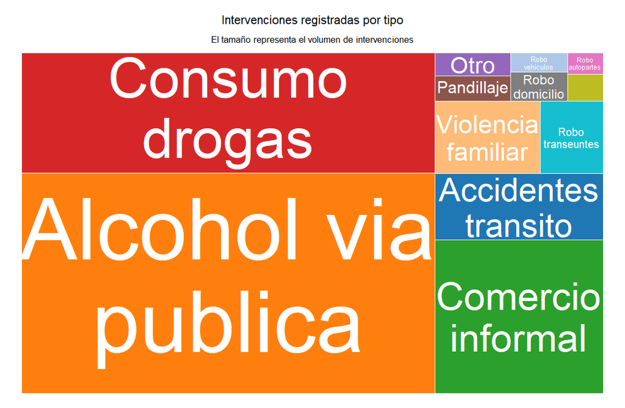

```r
intervenciones_tipo |>
  mutate(
    etiqueta = str_to_sentence(str_replace_all(tipo_intervencion, "_", " "))
  ) |>
  ggplot(aes(
    area = intervenciones,
    fill = tipo_intervencion,
    label = etiqueta
  )) +
  treemapify::geom_treemap(color = "white", linewidth = 0.8) +
  treemapify::geom_treemap_text(
    color = "white",
    place = "center",
    grow = TRUE,
    reflow = TRUE,
    min.size = 6
  ) +
  scale_fill_paletteer_d("ggsci::category20_d3", guide = "none") +
  labs(
    title = "Intervenciones registradas por tipo",
    subtitle = "El tamaño representa el volumen de intervenciones"
  ) +
  tema_sesion() +
  theme(
    axis.text = element_blank(),
    axis.title = element_blank(),
    panel.grid = element_blank()
  )
```

La visualización ayuda a priorizar categorías para discusión. En esta etapa no afirmamos causalidad: solo describimos el volumen registrado.

### 8.2 Intervenciones por departamento

```r
intervenciones_departamento <- renamu_seguridad |>
  group_by(departamento) |>
  summarise(
    municipalidades = n(),
    total_intervenciones = sum(total_intervenciones, na.rm = TRUE),
    promedio_intervenciones = mean(total_intervenciones, na.rm = TRUE),
    mediana_intervenciones = median(total_intervenciones, na.rm = TRUE),
    .groups = "drop"
  ) |>
  arrange(desc(total_intervenciones))

intervenciones_departamento
```

| departamento | municipalidades | total_intervenciones | promedio_intervenciones | mediana_intervenciones |
| --- | --- | --- | --- | --- |
| LIMA | 171 | 726911 | 726911 | 726911 |
| AREQUIPA | 109 | 106082 | 106082 | 106082 |
| CALLAO | 7 | 102572 | 102572 | 102572 |
| LA LIBERTAD | 84 | 49403 | 49403 | 49403 |
| JUNIN | 124 | 49302 | 49302 | 49302 |
| ANCASH | 166 | 22795 | 22795 | 22795 |
| CUSCO | 116 | 20474 | 20474 | 20474 |
| PIURA | 65 | 19057 | 19057 | 19057 |
| HUANUCO | 84 | 17800 | 17800 | 17800 |
| TACNA | 28 | 17595 | 17595 | 17595 |

[output cut: 15 more lines]

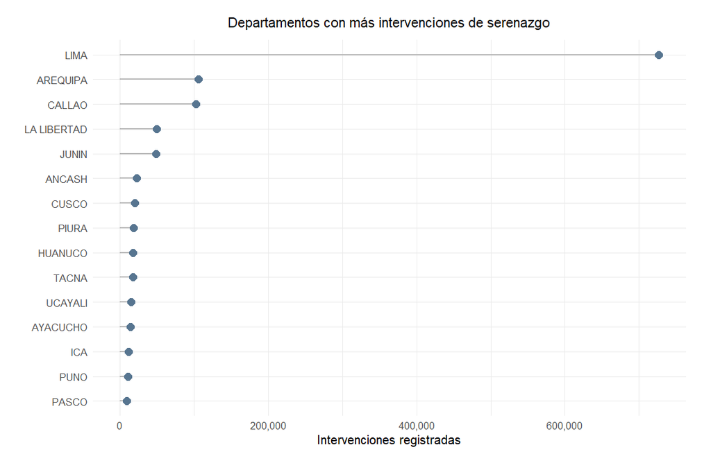

```r
intervenciones_departamento |>
  slice_max(total_intervenciones, n = 15) |>
  mutate(departamento = reorder(departamento, total_intervenciones)) |>
  ggplot(aes(x = total_intervenciones, y = departamento)) +
  geom_segment(
    aes(x = 0, xend = total_intervenciones, yend = departamento),
    color = "#b8b8b8",
    linewidth = 0.8
  ) +
  geom_point(size = 3.2, color = "#577590") +
  scale_x_continuous(labels = comma_format()) +
  labs(
    title = "Departamentos con más intervenciones de serenazgo",
    x = "Intervenciones registradas",
    y = NULL
  ) +
  tema_sesion()
```

Los departamentos con mayor volumen pueden reflejar mayor actividad, mayor población, mejor registro o una combinación de esas condiciones.

### 8.3 Municipalidades con más intervenciones

```r
renamu_seguridad |>
  arrange(desc(total_intervenciones)) |>
  select(
    departamento,
    provincia,
    distrito,
    tipo_municipalidad,
    total_intervenciones
  ) |>
  head(20)
```

| departamento | provincia | distrito | tipo_municipalidad | total_intervenciones |
| --- | --- | --- | --- | --- |
| LIMA | LIMA | SANTIAGO DE SURCO | Distrital | 84082 |
| LIMA | LIMA | SAN JUAN DE LURIGANCHO | Distrital | 79929 |
| CALLAO | CALLAO | VENTANILLA | Distrital | 71413 |
| LIMA | LIMA | LA MOLINA | Distrital | 58456 |
| LIMA | LIMA | SAN MARTIN DE PORRES | Distrital | 54635 |
| LIMA | LIMA | LIMA | Provincial | 53259 |
| LIMA | LIMA | LOS OLIVOS | Distrital | 42286 |
| LIMA | LIMA | LA VICTORIA | Distrital | 40041 |
| LIMA | LIMA | CARABAYLLO | Distrital | 37386 |
| LIMA | LIMA | COMAS | Distrital | 36753 |

[output cut: 10 more lines]

Revisar los casos extremos permite detectar municipalidades influyentes. Antes de graficar o modelar, conviene saber qué unidades explican buena parte del total.

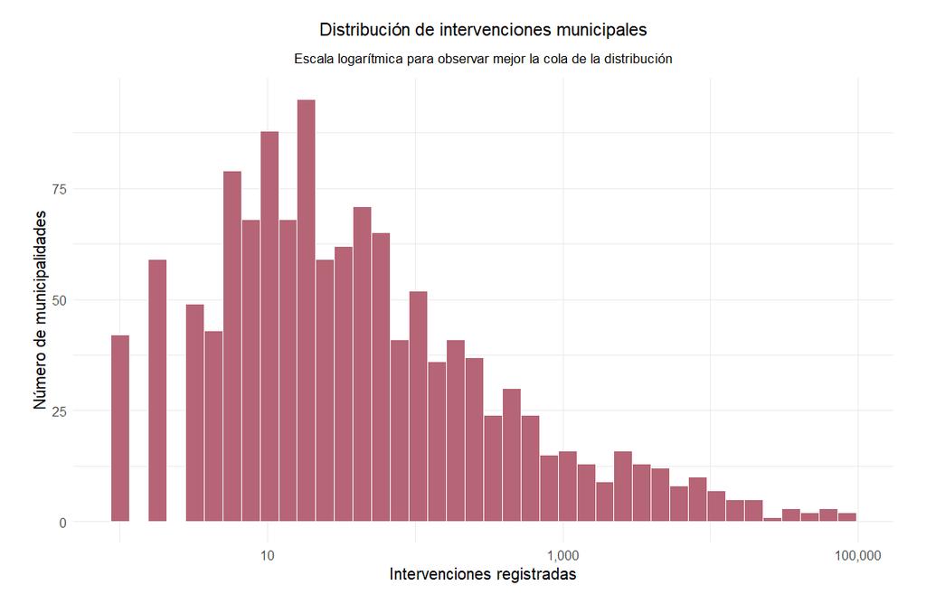

```r
renamu_seguridad |>
  filter(total_intervenciones > 0) |>
  ggplot(aes(x = total_intervenciones)) +
  geom_histogram(bins = 40, fill = "#b56576", color = "white") +
  scale_x_log10(labels = comma_format()) +
  labs(
    title = "Distribución de intervenciones municipales",
    subtitle = "Escala logarítmica para observar mejor la cola de la distribución",
    x = "Intervenciones registradas",
    y = "Número de municipalidades"
  ) +
  tema_sesion()
```

La escala logarítmica es útil cuando hay mucha concentración. No cambia los datos; solo facilita observar valores pequeños y grandes en el mismo gráfico.

## 9 Primer cruce descriptivo

### 9.1 Serenazgo, cámaras e intervenciones

```r
cruce_capacidad_intervenciones <- renamu_seguridad |>
  mutate(
    grupo_camaras = case_when(
      p70_7 == 1 ~ "Tiene cámaras",
      p70_7 == 2 ~ "No tiene cámaras",
      TRUE ~ "Sin dato"
    )
  ) |>
  group_by(grupo_camaras) |>
  summarise(
    municipalidades = n(),
    promedio_intervenciones = mean(total_intervenciones, na.rm = TRUE),
    mediana_intervenciones = median(total_intervenciones, na.rm = TRUE),
    .groups = "drop"
  )

cruce_capacidad_intervenciones
```

| grupo_camaras | municipalidades | promedio_intervenciones | mediana_intervenciones |
| --- | --- | --- | --- |
| No tiene cámaras | 1257 | 48.96659 | 2 |
| Tiene cámaras | 634 | 1868.27603 | 57 |

Este cruce sigue siendo descriptivo: compara intervenciones según disponibilidad de cámaras. No prueba que las cámaras causen más o menos intervenciones.

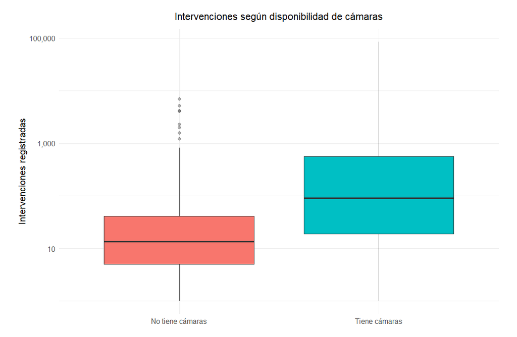

```r
renamu_seguridad |>
  filter(p70_7 %in% c(1, 2), total_intervenciones > 0) |>
  mutate(
    grupo_camaras = if_else(p70_7 == 1, "Tiene cámaras", "No tiene cámaras")
  ) |>
  ggplot(aes(
    x = grupo_camaras,
    y = total_intervenciones,
    fill = grupo_camaras
  )) +
  geom_boxplot(show.legend = FALSE, outlier.alpha = 0.35) +
  scale_y_log10(labels = comma_format()) +
  labs(
    title = "Intervenciones según disponibilidad de cámaras",
    x = NULL,
    y = "Intervenciones registradas"
  ) +
  tema_sesion()
```

La comparación sugiere diferencias de distribución entre municipalidades con y sin cámaras. Para interpretarla mejor harían falta controles por población, urbanidad y capacidad administrativa.

## 10 Galería aplicada de visualizaciones

Esta sección usa varias familias de gráficos como una caja de herramientas. La pregunta no es “qué gráfico se ve mejor”, sino qué forma visual ayuda a entender mejor una variable, una comparación o una relación.

### 10.1 Histograma y densidad

Pregunta: ¿la mayoría de municipalidades tiene pocos o muchos efectivos de serenazgo?

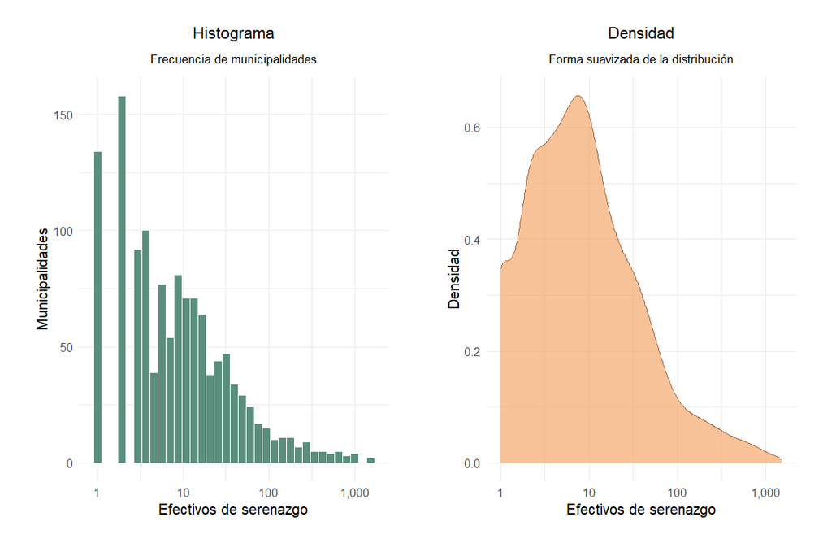

```r
preparar_renamu_seguridad()

datos_efectivos <- renamu_seguridad |>
  filter(p69_2 == 1, !is.na(p69_2_t), p69_2_t > 0)

grafico_histograma <- datos_efectivos |>
  ggplot(aes(x = p69_2_t)) +
  geom_histogram(bins = 35, fill = "#5b8e7d", color = "white") +
  scale_x_log10(labels = comma_format()) +
  labs(
    title = "Histograma",
    subtitle = "Frecuencia de municipalidades",
    x = "Efectivos de serenazgo",
    y = "Municipalidades"
  ) +
  tema_sesion()

grafico_densidad <- datos_efectivos |>
  ggplot(aes(x = p69_2_t)) +
  geom_density(fill = "#f4a261", alpha = 0.65, color = "#9c6644") +
  scale_x_log10(labels = comma_format()) +
  labs(
    title = "Densidad",
    subtitle = "Forma suavizada de la distribución",
    x = "Efectivos de serenazgo",
    y = "Densidad"
  ) +
  tema_sesion()

grafico_histograma + grafico_densidad
```

El histograma muestra conteos por intervalos; la densidad ayuda a ver la forma general de la distribución. En ambos usamos escala logarítmica porque hay pocas municipalidades con muchos efectivos.

### 10.2 Violin y beeswarm

Pregunta: ¿las municipalidades provinciales y distritales tienen distribuciones parecidas de efectivos?

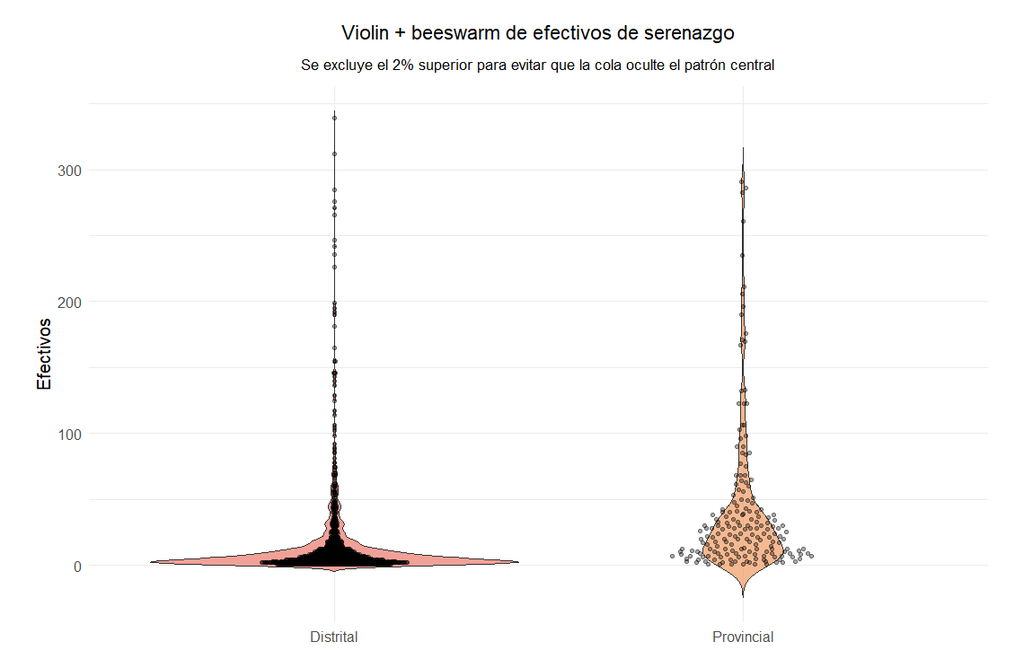

```r
datos_efectivos |>
  filter(p69_2_t <= quantile(p69_2_t, 0.98, na.rm = TRUE)) |>
  ggplot(aes(x = tipo_municipalidad, y = p69_2_t, fill = tipo_municipalidad)) +
  geom_violin(alpha = 0.6, show.legend = FALSE, trim = FALSE) +
  ggbeeswarm::geom_quasirandom(
    width = 0.18,
    alpha = 0.35,
    size = 1.2,
    show.legend = FALSE
  ) +
  scale_fill_paletteer_d("MetBrewer::Hiroshige") +
  scale_y_continuous(labels = comma_format()) +
  labs(
    title = "Violin + beeswarm de efectivos de serenazgo",
    subtitle = "Se excluye el 2% superior para evitar que la cola oculte el patrón central",
    x = NULL,
    y = "Efectivos"
  ) +
  tema_sesion()
```

El violin permite comparar la forma de la distribución; el beeswarm muestra cada municipalidad como un punto. Esta combinación evita esconder los datos detrás de una sola caja.

### 10.3 Ridgeline por departamento

Pregunta: ¿en qué departamentos los efectivos se concentran en pocas municipalidades y en cuáles se distribuyen más?

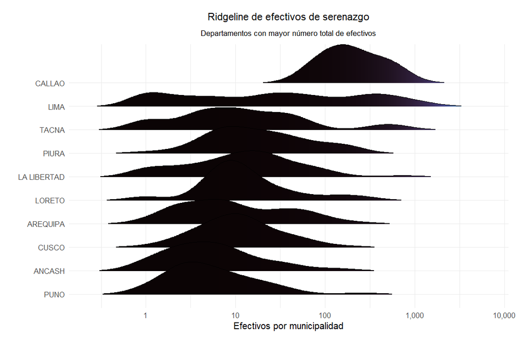

```r
departamentos_top_efectivos <- datos_efectivos |>
  group_by(departamento) |>
  summarise(total_efectivos = sum(p69_2_t, na.rm = TRUE), .groups = "drop") |>
  slice_max(total_efectivos, n = 10)

datos_efectivos |>
  semi_join(departamentos_top_efectivos, by = "departamento") |>
  filter(p69_2_t > 0) |>
  ggplot(aes(
    x = p69_2_t,
    y = reorder(departamento, p69_2_t),
    fill = after_stat(x)
  )) +
  ggridges::geom_density_ridges_gradient(
    scale = 1.7,
    rel_min_height = 0.01,
    alpha = 0.85
  ) +
  scale_x_log10(labels = comma_format()) +
  scale_fill_paletteer_c("viridis::mako", guide = "none") +
  labs(
    title = "Ridgeline de efectivos de serenazgo",
    subtitle = "Departamentos con mayor número total de efectivos",
    x = "Efectivos por municipalidad",
    y = NULL
  ) +
  tema_sesion()
```

El ridgeline sirve para comparar distribuciones entre varios grupos sin multiplicar demasiados gráficos. Aquí ayuda a ver si un departamento concentra efectivos en pocas municipalidades o si la distribución es más extendida.

### 10.4 Lollipop de ranking

Pregunta: ¿qué municipalidades concentran el mayor número de intervenciones registradas por serenazgo?

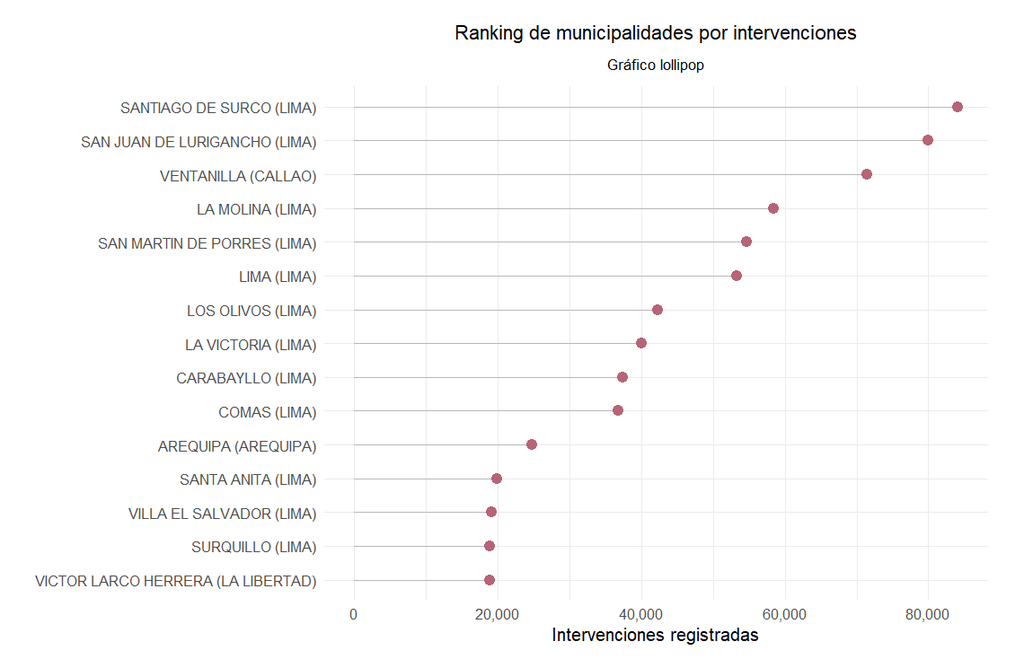

```r
renamu_seguridad |>
  arrange(desc(total_intervenciones)) |>
  slice_head(n = 15) |>
  mutate(municipalidad = str_c(distrito, " (", departamento, ")")) |>
  ggplot(aes(
    x = total_intervenciones,
    y = reorder(municipalidad, total_intervenciones)
  )) +
  geom_segment(
    aes(x = 0, xend = total_intervenciones, yend = municipalidad),
    color = "#b8b8b8"
  ) +
  geom_point(size = 3, color = "#b56576") +
  scale_x_continuous(labels = comma_format()) +
  labs(
    title = "Ranking de municipalidades por intervenciones",
    subtitle = "Gráfico lollipop",
    x = "Intervenciones registradas",
    y = NULL
  ) +
  tema_sesion()
```

El lollipop es una alternativa más liviana al barplot cuando queremos mostrar un ranking. Funciona bien si el interés está en el orden y la distancia entre casos.

### 10.5 Barras agrupadas y apiladas

Pregunta: ¿las municipalidades provinciales y distritales tienen el mismo perfil de recursos para serenazgo?

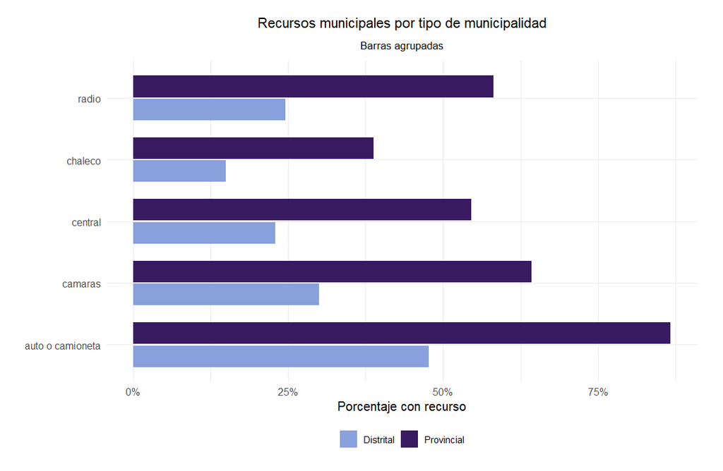

```r
recursos_tipo <- renamu_seguridad |>
  group_by(tipo_municipalidad) |>
  summarise(
    auto_o_camioneta = mean(p70_1 == 1, na.rm = TRUE),
    radio = mean(p70_6 == 1, na.rm = TRUE),
    camaras = mean(p70_7 == 1, na.rm = TRUE),
    central = mean(p70_10 == 1, na.rm = TRUE),
    chaleco = mean(p70_13 == 1, na.rm = TRUE),
    .groups = "drop"
  ) |>
  pivot_longer(
    cols = -tipo_municipalidad,
    names_to = "recurso",
    values_to = "porcentaje"
  ) |>
  mutate(recurso = str_replace_all(recurso, "_", " "))

recursos_tipo |>
  ggplot(aes(x = recurso, y = porcentaje, fill = tipo_municipalidad)) +
  geom_col(position = position_dodge(width = 0.75), width = 0.7) +
  coord_flip() +
  scale_y_continuous(labels = percent_format()) +
  scale_fill_paletteer_d("MetBrewer::Archambault") +
  labs(
    title = "Recursos municipales por tipo de municipalidad",
    subtitle = "Barras agrupadas",
    x = NULL,
    y = "Porcentaje con recurso",
    fill = NULL
  ) +
  tema_sesion()
```

Las barras agrupadas comparan porcentajes entre dos grupos. Aquí permiten ver diferencias entre municipalidades provinciales y distritales en capacidades de serenazgo.

Pregunta: ¿cómo cambia la composición relativa de recursos entre tipos de municipalidad?

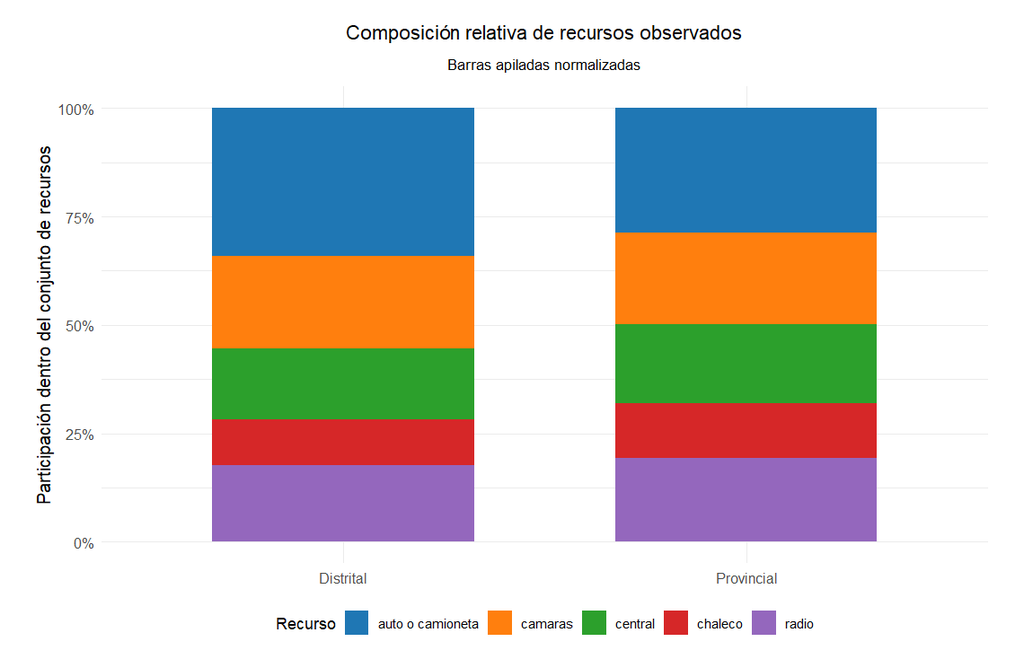

```r
recursos_tipo |>
  group_by(tipo_municipalidad) |>
  mutate(participacion = porcentaje / sum(porcentaje, na.rm = TRUE)) |>
  ungroup() |>
  ggplot(aes(x = tipo_municipalidad, y = participacion, fill = recurso)) +
  geom_col(width = 0.65) +
  scale_y_continuous(labels = percent_format()) +
  scale_fill_paletteer_d("ggsci::category20_d3") +
  labs(
    title = "Composición relativa de recursos observados",
    subtitle = "Barras apiladas normalizadas",
    x = NULL,
    y = "Participación dentro del conjunto de recursos",
    fill = "Recurso"
  ) +
  tema_sesion()
```

Las barras apiladas normalizadas muestran composición, no volumen absoluto. Sirven para comparar perfiles, pero no reemplazan el gráfico anterior.

### 10.6 Bubble plot interactivo

Pregunta: ¿los departamentos con más efectivos y cámaras son también los que registran más intervenciones?

```r
indicadores_burbujas <- renamu_seguridad |>
  group_by(departamento) |>
  summarise(
    municipalidades = n(),
    efectivos = sum(p69_2_t, na.rm = TRUE),
    camaras = sum(p70a_7_1, na.rm = TRUE),
    intervenciones = sum(total_intervenciones, na.rm = TRUE),
    porcentaje_serenazgo = mean(p69_2 == 1, na.rm = TRUE),
    .groups = "drop"
  )

plotly::plot_ly(
  data = indicadores_burbujas,
  x = ~efectivos,
  y = ~intervenciones,
  type = "scatter",
  mode = "markers",
  size = ~camaras,
  color = ~porcentaje_serenazgo,
  colors = c("#0d0887", "#7e03a8", "#cc4778", "#f89540", "#f0f921"),
  sizes = c(8, 38),
  marker = list(opacity = 0.75, line = list(width = 1, color = "white")),
  text = ~ str_c(
    departamento,
    "<br>Efectivos: ",
    comma(efectivos),
    "<br>Intervenciones: ",
    comma(intervenciones),
    "<br>Cámaras: ",
    comma(camaras),
    "<br>% con serenazgo: ",
    percent(porcentaje_serenazgo, accuracy = 0.1)
  ),
  hoverinfo = "text"
) |>
  plotly::layout(
    title = "Capacidad municipal e intervenciones por departamento",
    xaxis = list(title = "Efectivos de serenazgo", type = "log"),
    yaxis = list(title = "Intervenciones registradas", type = "log"),
    legend = list(orientation = "h", x = 0, y = -0.2)
  )
```

[interactive chart not shown]

El bubble plot permite ver tres dimensiones a la vez: efectivos, intervenciones y cámaras. Con `plotly`, el gráfico se vuelve interactivo y permite consultar cada departamento. Usamos `plot_ly()` directamente porque suele ser más estable que convertir un gráfico complejo desde `ggplot2`.

Sin embargo, este bloque solo se activará en el renderizado HTML por motivos de compatibilidad.

### 10.7 Heatmap de intervenciones

Pregunta: ¿qué tipos de intervención pesan más dentro de cada departamento?

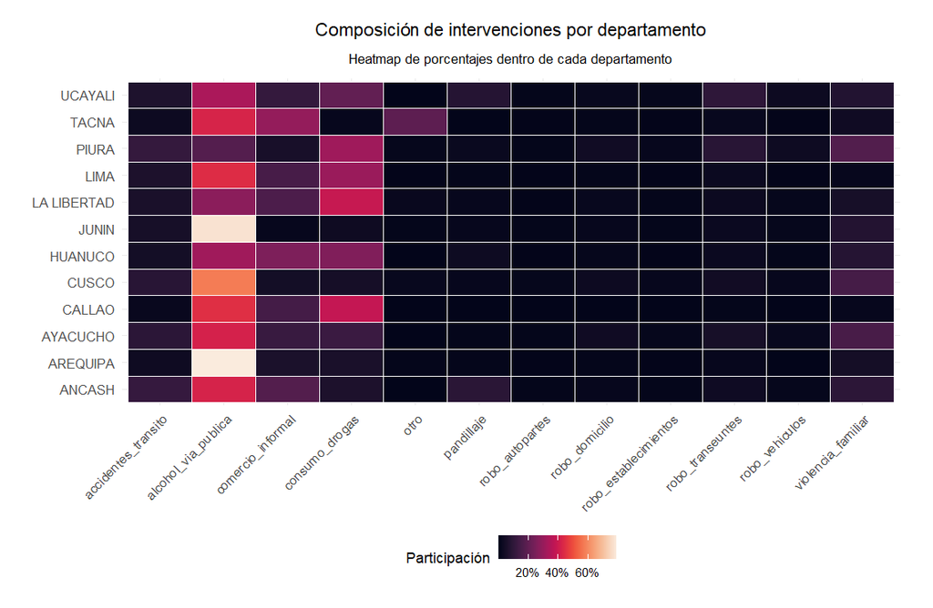

```r
intervenciones_larga |>
  group_by(departamento, tipo_intervencion) |>
  summarise(
    intervenciones = sum(intervenciones, na.rm = TRUE),
    .groups = "drop"
  ) |>
  group_by(departamento) |>
  mutate(participacion = intervenciones / sum(intervenciones, na.rm = TRUE)) |>
  ungroup() |>
  semi_join(
    intervenciones_departamento |> slice_max(total_intervenciones, n = 12),
    by = "departamento"
  ) |>
  ggplot(aes(
    x = tipo_intervencion,
    y = reorder(departamento, participacion),
    fill = participacion
  )) +
  geom_tile(color = "white", linewidth = 0.2) +
  scale_fill_paletteer_c("viridis::rocket", labels = percent_format()) +
  labs(
    title = "Composición de intervenciones por departamento",
    subtitle = "Heatmap de porcentajes dentro de cada departamento",
    x = NULL,
    y = NULL,
    fill = "Participación"
  ) +
  tema_sesion() +
  theme(axis.text.x = element_text(angle = 45, hjust = 1))
```

El heatmap ayuda cuando tenemos dos dimensiones categóricas. Aquí permite ver qué tipos de intervención pesan más dentro de cada departamento.

### 10.8 Correlograma de indicadores

Pregunta: ¿qué indicadores municipales tienden a moverse juntos?

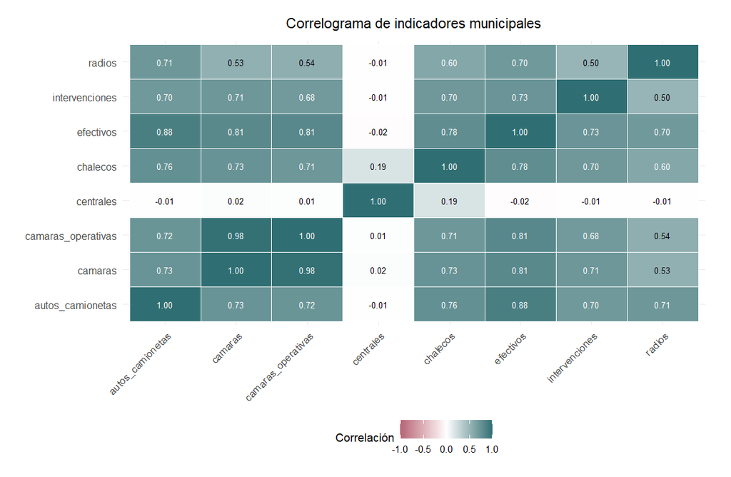

```r
indicadores_correlacion <- renamu_seguridad |>
  transmute(
    efectivos = p69_2_t,
    autos_camionetas = p70a_1_1,
    radios = p70a_6_1,
    camaras = p70a_7_1,
    camaras_operativas = p70a_7_2,
    centrales = p70a_10_1,
    chalecos = p70a_13_1,
    intervenciones = total_intervenciones
  )

correlaciones <- cor(
  indicadores_correlacion,
  use = "pairwise.complete.obs"
) |>
  as.data.frame() |>
  rownames_to_column("variable_1") |>
  pivot_longer(
    cols = -variable_1,
    names_to = "variable_2",
    values_to = "correlacion"
  )

correlaciones |>
  mutate(color_texto = if_else(abs(correlacion) > 0.55, "white", "black")) |>
  ggplot(aes(x = variable_1, y = variable_2, fill = correlacion)) +
  geom_tile(color = "white", linewidth = 0.25) +
  geom_text(
    aes(label = number(correlacion, accuracy = 0.01), color = color_texto),
    size = 2.8
  ) +
  scale_fill_gradient2(
    low = "#b56576",
    mid = "white",
    high = "#2f6f73",
    midpoint = 0,
    limits = c(-1, 1)
  ) +
  scale_color_identity() +
  labs(
    title = "Correlograma de indicadores municipales",
    x = NULL,
    y = NULL,
    fill = "Correlación"
  ) +
  tema_sesion() +
  theme(axis.text.x = element_text(angle = 45, hjust = 1))
```

El correlograma resume relaciones lineales entre variables numéricas. En esta sesión lo usamos como exploración, no como evidencia causal.

### 10.9 Dispersión y densidad 2D

Pregunta: ¿hay relación entre tener más cámaras operativas y registrar más intervenciones?

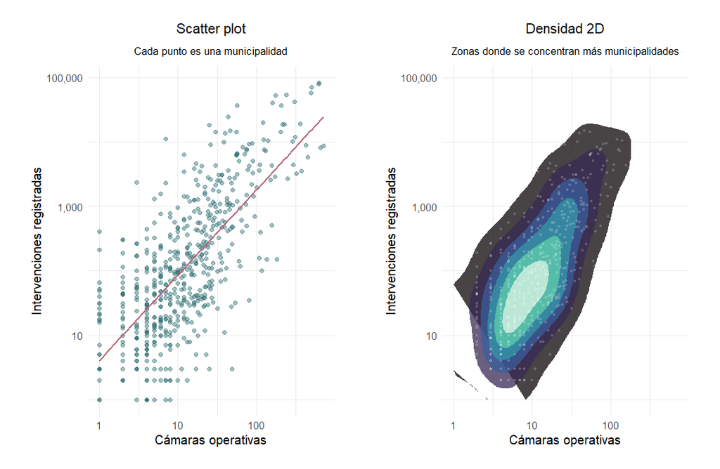

```r
datos_camaras_intervenciones <- renamu_seguridad |>
  filter(
    !is.na(p70a_7_2),
    p70a_7_2 > 0,
    total_intervenciones > 0
  )

grafico_dispersion <- datos_camaras_intervenciones |>
  ggplot(aes(x = p70a_7_2, y = total_intervenciones)) +
  geom_point(alpha = 0.45, color = "#2f6f73") +
  geom_smooth(method = "lm", se = FALSE, color = "#b56576", linewidth = 0.8) +
  scale_x_log10(labels = comma_format()) +
  scale_y_log10(labels = comma_format()) +
  labs(
    title = "Scatter plot",
    subtitle = "Cada punto es una municipalidad",
    x = "Cámaras operativas",
    y = "Intervenciones registradas"
  ) +
  tema_sesion()

grafico_densidad_2d <- datos_camaras_intervenciones |>
  ggplot(aes(x = p70a_7_2, y = total_intervenciones)) +
  stat_density_2d(
    aes(fill = after_stat(level)),
    geom = "polygon",
    alpha = 0.75
  ) +
  geom_point(alpha = 0.15, size = 0.8, color = "white") +
  scale_x_log10(labels = comma_format()) +
  scale_y_log10(labels = comma_format()) +
  scale_fill_paletteer_c("viridis::mako", guide = "none") +
  labs(
    title = "Densidad 2D",
    subtitle = "Zonas donde se concentran más municipalidades",
    x = "Cámaras operativas",
    y = "Intervenciones registradas"
  ) +
  tema_sesion()

grafico_dispersion + grafico_densidad_2d
```

El scatter muestra casos individuales; la densidad 2D muestra dónde se agrupan. Cuando hay muchos puntos y una cola larga, mirar ambas versiones evita sobreinterpretar casos extremos.

### 10.10 Treemap de intervenciones

Pregunta: ¿qué tipos de intervención ocupan la mayor parte del total registrado?

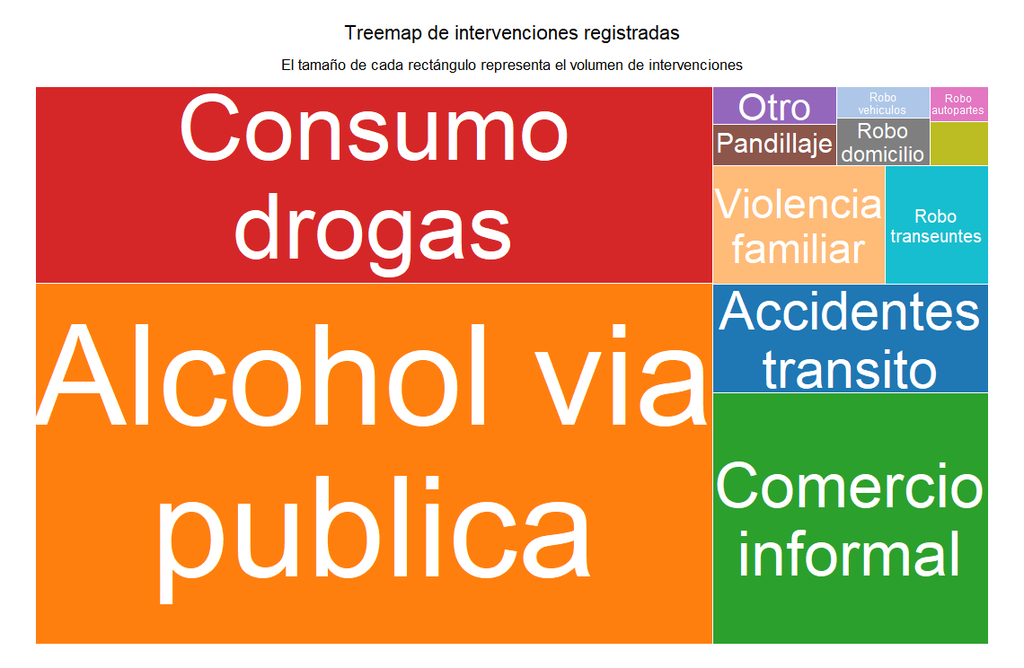

```r
intervenciones_tipo |>
  mutate(
    etiqueta = str_replace_all(tipo_intervencion, "_", " "),
    etiqueta = str_to_sentence(etiqueta)
  ) |>
  ggplot(aes(
    area = intervenciones,
    fill = tipo_intervencion,
    label = etiqueta
  )) +
  treemapify::geom_treemap(color = "white", linewidth = 0.8) +
  treemapify::geom_treemap_text(
    color = "white",
    place = "center",
    grow = TRUE,
    reflow = TRUE,
    min.size = 6
  ) +
  scale_fill_paletteer_d("ggsci::category20_d3", guide = "none") +
  labs(
    title = "Treemap de intervenciones registradas",
    subtitle = "El tamaño de cada rectángulo representa el volumen de intervenciones"
  ) +
  tema_sesion() +
  theme(
    axis.text = element_blank(),
    axis.title = element_blank(),
    panel.grid = element_blank()
  )
```

El treemap funciona para mostrar partes de un total cuando hay varias categorías. Es menos preciso que una barra ordenada, pero ayuda a comunicar concentración.

### 10.11 Heatmap de recursos categóricos

Pregunta: ¿qué tan frecuente es que una municipalidad tenga central de videovigilancia y chalecos antibalas al mismo tiempo?

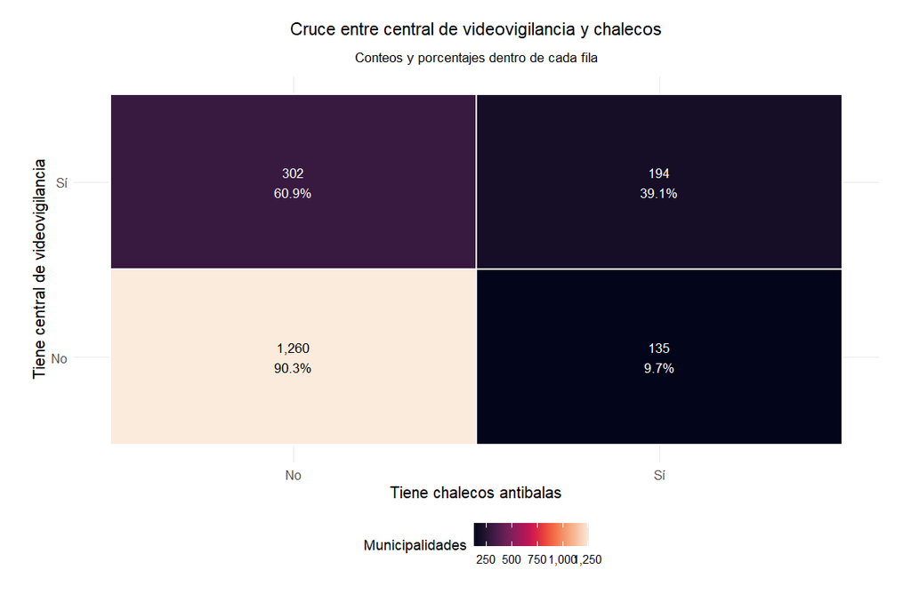

```r
renamu_seguridad |>
  mutate(
    central = etiquetar_si_no(p70_10),
    chaleco = etiquetar_si_no(p70_13)
  ) |>
  filter(central %in% c("Sí", "No"), chaleco %in% c("Sí", "No")) |>
  count(central, chaleco, name = "municipalidades") |>
  group_by(central) |>
  mutate(porcentaje_fila = municipalidades / sum(municipalidades)) |>
  ungroup() |>
  mutate(color_texto = if_else(municipalidades < 500, "white", "black")) |>
  ggplot(aes(x = chaleco, y = central, fill = municipalidades)) +
  geom_tile(color = "white", linewidth = 0.8) +
  geom_text(
    aes(
      label = str_c(
        comma(municipalidades),
        "\n",
        percent(porcentaje_fila, accuracy = 0.1)
      ),
      color = color_texto
    ),
    size = 3.6
  ) +
  scale_fill_paletteer_c("viridis::rocket", labels = comma_format()) +
  scale_color_identity() +
  labs(
    title = "Cruce entre central de videovigilancia y chalecos",
    subtitle = "Conteos y porcentajes dentro de cada fila",
    x = "Tiene chalecos antibalas",
    y = "Tiene central de videovigilancia",
    fill = "Municipalidades"
  ) +
  tema_sesion()
```

Este heatmap trabaja con dos variables categóricas. Es una forma compacta de leer combinaciones, no solo porcentajes separados.

### 10.12 Base complementaria de celulares

Pregunta: ¿en qué departamentos se concentran los registros de robo de celular de la base complementaria?

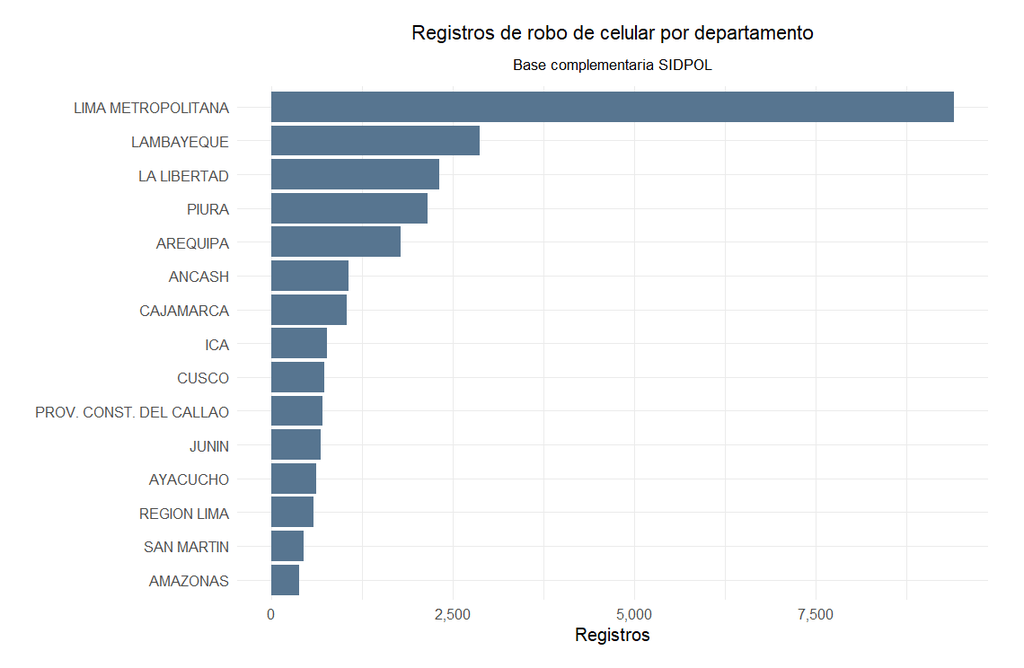

```r
preparar_base_celular()

celular_departamento <- base_celular |>
  count(dpto_hecho_new, sort = TRUE, name = "denuncias") |>
  filter(!is.na(dpto_hecho_new)) |>
  slice_max(denuncias, n = 15)

celular_departamento |>
  ggplot(aes(x = denuncias, y = reorder(dpto_hecho_new, denuncias))) +
  geom_col(fill = "#577590") +
  scale_x_continuous(labels = comma_format()) +
  labs(
    title = "Registros de robo de celular por departamento",
    subtitle = "Base complementaria SIDPOL",
    x = "Registros",
    y = NULL
  ) +
  tema_sesion()
```

Esta visualización usa una base complementaria para practicar ranking con registros policiales. La lectura es descriptiva: muestra concentración territorial de los registros disponibles.

Pregunta: ¿la edad de las personas registradas cambia según sexo?

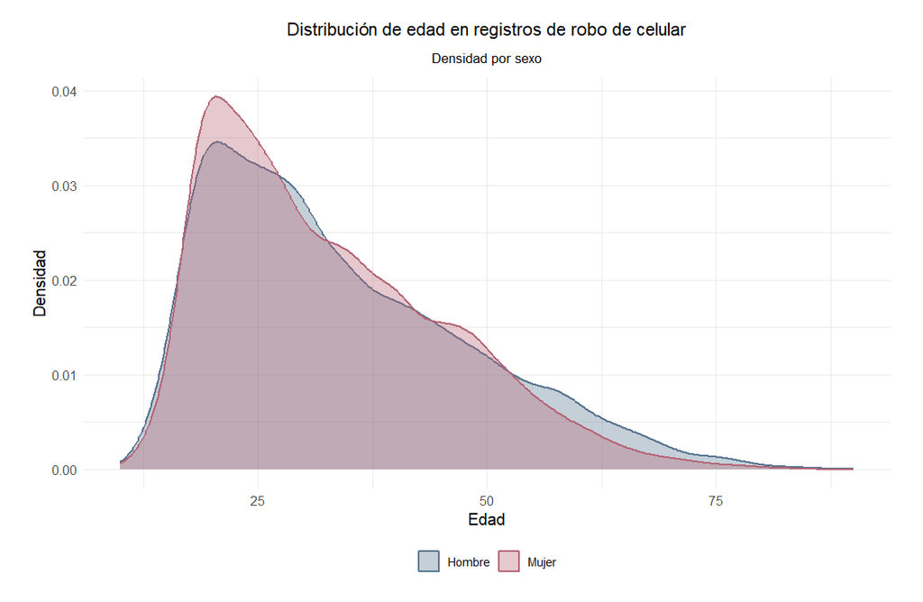

```r
base_celular |>
  filter(
    sexo %in% c("Mujer", "Hombre"),
    !is.na(edad),
    edad >= 10,
    edad <= 90
  ) |>
  ggplot(aes(x = edad, fill = sexo, color = sexo)) +
  geom_density(alpha = 0.35, linewidth = 0.8) +
  scale_fill_manual(values = c("Mujer" = "#b56576", "Hombre" = "#577590")) +
  scale_color_manual(values = c("Mujer" = "#b56576", "Hombre" = "#577590")) +
  labs(
    title = "Distribución de edad en registros de robo de celular",
    subtitle = "Densidad por sexo",
    x = "Edad",
    y = "Densidad",
    fill = NULL,
    color = NULL
  ) +
  tema_sesion()
```

La densidad por sexo permite comparar formas de distribución, no solo promedios. Aquí interesa ver si las edades se concentran en rangos similares o distintos.

### 10.13 Serie temporal con archivo complementario

Pregunta: ¿cómo evolucionan algunos indicadores operativos a lo largo del tiempo?

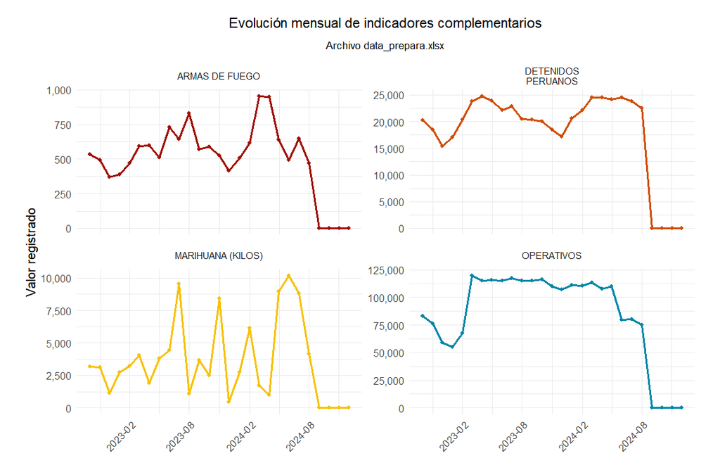

```r
preparar_data_prepara()

variables_tiempo <- c(
  "OPERATIVOS",
  "ARMAS DE FUEGO",
  "DETENIDOS DIVERSOS DELITOS (PERUANOS)",
  "MARIHUANA (KILOS)"
)

serie_tiempo <- data_prepara |>
  filter(variable %in% variables_tiempo) |>
  group_by(fecha, variable) |>
  summarise(valor = sum(valor, na.rm = TRUE), .groups = "drop") |>
  mutate(
    variable_grafico = recode(
      variable,
      "DETENIDOS DIVERSOS DELITOS (PERUANOS)" = "DETENIDOS\nPERUANOS"
    )
  )

serie_tiempo |>
  ggplot(aes(x = fecha, y = valor, color = variable)) +
  geom_line(linewidth = 0.9, show.legend = FALSE) +
  geom_point(size = 1.4, show.legend = FALSE) +
  facet_wrap(~variable_grafico, scales = "free_y", ncol = 2) +
  scale_x_date(date_breaks = "6 months", date_labels = "%Y-%m") +
  scale_y_continuous(labels = comma_format()) +
  scale_color_paletteer_d("MetBrewer::Johnson") +
  labs(
    title = "Evolución mensual de indicadores complementarios",
    subtitle = "Archivo data_prepara.xlsx",
    x = NULL,
    y = "Valor registrado"
  ) +
  tema_sesion() +
  theme(axis.text.x = element_text(angle = 45, hjust = 1))
```

Los gráficos de línea son adecuados cuando hay una dimensión temporal. Aquí el objetivo es mostrar evolución, estacionalidad y posibles picos.

Pregunta: ¿las series tienen patrones temporales parecidos aunque estén en escalas distintas?

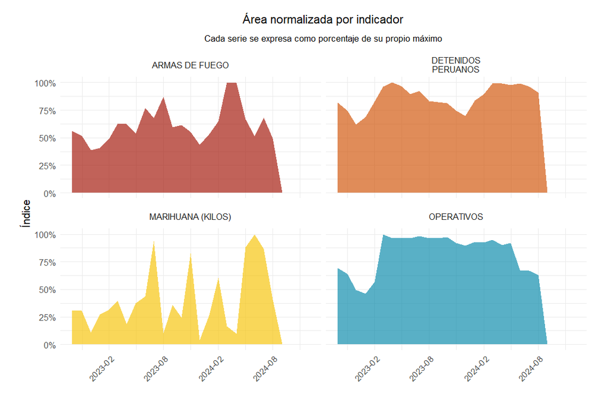

```r
serie_tiempo |>
  group_by(variable) |>
  mutate(indice = valor / max(valor, na.rm = TRUE)) |>
  ungroup() |>
  ggplot(aes(x = fecha, y = indice, fill = variable)) +
  geom_area(alpha = 0.65, position = "identity", show.legend = FALSE) +
  facet_wrap(~variable_grafico, ncol = 2) +
  scale_x_date(date_breaks = "6 months", date_labels = "%Y-%m") +
  scale_y_continuous(labels = percent_format()) +
  scale_fill_paletteer_d("MetBrewer::Johnson") +
  labs(
    title = "Área normalizada por indicador",
    subtitle = "Cada serie se expresa como porcentaje de su propio máximo",
    x = NULL,
    y = "Índice"
  ) +
  tema_sesion() +
  theme(
    axis.text.x = element_text(angle = 45, hjust = 1),
    strip.text = element_text(size = 9.5)
  )
```

El área normalizada no compara magnitudes absolutas, sino patrones de evolución. Es útil cuando las variables tienen escalas muy distintas.

## 11 Diccionario mínimo de trabajo

```r
diccionario_sesion_3 <- tibble(
  variable = c(
    "ubigeo",
    "departamento",
    "provincia",
    "distrito",
    "tipo_municipalidad",
    "p69_2",
    "p69_2_t",
    "p70_7",
    "p70a_7_1",
    "p70a_7_2",
    "p70a_7_4",
    "p70_10",
    "total_intervenciones"
  ),
  descripcion = c(
    "Código territorial de seis dígitos.",
    "Departamento de la municipalidad.",
    "Provincia de la municipalidad.",
    "Distrito de la municipalidad.",
    "Tipo de municipalidad: provincial o distrital.",
    "Indica si la municipalidad brindó serenazgo al 31 de marzo de 2025.",
    "Total de efectivos de serenazgo al 31 de marzo de 2025.",
    "Indica si la municipalidad dispone de cámaras de videovigilancia.",
    "Total de cámaras de videovigilancia.",
    "Cámaras de videovigilancia operativas.",
    "Cámaras operativas integradas a la PNP.",
    "Indica si el serenazgo dispone de central de control de videovigilancia.",
    "Suma de intervenciones registradas por serenazgo en las categorías P71."
  ),
  fuente = "RENAMU 2025"
)

diccionario_sesion_3
```

| variable | descripcion | fuente |
| --- | --- | --- |
| ubigeo | Código territorial de seis dígitos. | RENAMU 2025 |
| departamento | Departamento de la municipalidad. | RENAMU 2025 |
| provincia | Provincia de la municipalidad. | RENAMU 2025 |
| distrito | Distrito de la municipalidad. | RENAMU 2025 |
| tipo_municipalidad | Tipo de municipalidad: provincial o distrital. | RENAMU 2025 |
| p69_2 | Indica si la municipalidad brindó serenazgo al 31 de marzo de 2025. | RENAMU 2025 |
| p69_2_t | Total de efectivos de serenazgo al 31 de marzo de 2025. | RENAMU 2025 |
| p70_7 | Indica si la municipalidad dispone de cámaras de videovigilancia. | RENAMU 2025 |
| p70a_7_1 | Total de cámaras de videovigilancia. | RENAMU 2025 |
| p70a_7_2 | Cámaras de videovigilancia operativas. | RENAMU 2025 |

[output cut: 3 more lines]

El diccionario mínimo traduce códigos de cuestionario a variables interpretables. Esta práctica evita que el análisis dependa de memoria o de nombres crípticos.

## 12 Exportar resultados

```r
base_renamu_seguridad <- renamu_seguridad |>
  select(
    ano,
    ubigeo,
    departamento,
    provincia,
    distrito,
    tipo_municipalidad,
    serenazgo_2024,
    serenazgo_2025,
    p69_2_t,
    p69_2_m,
    p69_2_h,
    tiene_auto_camioneta,
    p70a_1_1,
    p70a_1_2,
    p70a_1_3,
    tiene_radio,
    p70a_6_1,
    p70a_6_2,
    p70a_6_3,
    tiene_camaras,
    p70a_7_1,
    p70a_7_2,
    p70a_7_3,
    p70a_7_4,
    tiene_central_videovigilancia,
    p70a_10_1,
    p70a_10_2,
    p70a_10_3,
    tiene_chaleco_antibalas,
    p70a_13_1,
    total_intervenciones
  )

indicadores_departamento <- renamu_seguridad |>
  group_by(departamento) |>
  summarise(
    municipalidades = n(),
    con_serenazgo = sum(p69_2 == 1, na.rm = TRUE),
    porcentaje_serenazgo = con_serenazgo / municipalidades,
    efectivos_serenazgo = sum(p69_2_t, na.rm = TRUE),
    con_camaras = sum(p70_7 == 1, na.rm = TRUE),
    total_camaras = sum(p70a_7_1, na.rm = TRUE),
    camaras_operativas = sum(p70a_7_2, na.rm = TRUE),
    intervenciones_serenazgo = sum(total_intervenciones, na.rm = TRUE),
    .groups = "drop"
  )

write_csv(
  base_renamu_seguridad,
  file.path(ruta_resultados, "base_sesion3.csv")
)

write_csv(
  indicadores_departamento,
  file.path(ruta_resultados, "indicadores_sesion3.csv")
)

write_csv(
  diccionario_sesion_3,
  file.path(ruta_resultados, "diccionario_sesion3.csv")
)
```

La exportación deja una base municipal simplificada, un resumen departamental y un diccionario mínimo. Esos productos pueden reutilizarse para tareas o para sesiones posteriores.

## 13 Ejercicios para seguir practicando

1. Identificar los cinco departamentos con mayor porcentaje de municipalidades con serenazgo.
2. Calcular el porcentaje de cámaras operativas por departamento.
3. Encontrar municipalidades que declaran tener cámaras, pero registran cero cámaras operativas.
4. Comparar la mediana de intervenciones entre municipalidades provinciales y distritales.
5. Crear un gráfico de barras con los tres tipos de intervención más frecuentes.
6. Revisar si las municipalidades con central de videovigilancia tienen más cámaras operativas.
7. Exportar una base solo con municipalidades de Lima Metropolitana o Callao.

Estos ejercicios pueden apoyarse en el Posit Assistant de RStudio para revisar errores, pedir explicaciones de código y explorar alternativas de limpieza o visualización.